# CA5: Implementing Neural Networks from scratch

Danial Saeedi(810198571)

```python
import numpy as np
import pandas as pd
import matplotlib.pyplot as plt
import copy
```

# Dataloader

```python
class Dataloader:
    '''
    This class prepares the dataset for the neural network.
    '''

    def __init__(self, data, labels, n_classes, batch_size=None, shuffle=False):
        '''
        This is the constructor. It gets dataset information and initializes the
        Dataloader class fields.
            Parameters:
                data: features your dataset in pandas.Dataframe format.
                labels: labels of your dataset in pandas.Dataframe format.
                n_classes: number of classes you have in your dataset.
                batch_size: the number of samples that will be propagated through the network.
                shuffle: boolean value indicating whether or not the dataset should be shuffled
        '''

        assert len(data)==len(labels)
        self.__n_classes = n_classes
        self.__batch_size = batch_size
        self.__shuffle = shuffle
        self.__data = data
        self.__onehot_labels = self.__onehot(labels, self.__n_classes)

    def __onehot(self, labels, n_classes):
        '''
        This private method gets labels and provides one_hot vectors of labels.
        For categorical variables where no such ordinal relationship exists,
        the integer encoding is not enough.
        In this case, a one-hot encoding can be applied to the integer representation.
        This is where the integer encoded variable is removed, and a new binary variable is
        added for each unique integer value.
        example:
            red,    green,    blue
            1,      0,        0
            0,      1,        0
            0,      0,        1
                Parameters:
                        label: lables of your dataset in pandas.Dataframe format.
                        n_classes: number of classes you have in your dataset.

                Returns:
                    onehot_vectors: onehot vectors of the labels
        '''
        result = list()
        for label in labels:
            result.append([0 for i in range(n_classes)])
            result[len(result)-1][int(label)] = 1
        return np.array(result)

    def __shuffle_dataset(self):
        '''
        This private method shuffles your dataset.
        It uses data and onehot_labels to shuffle them
        symmetrical.
        '''
        random_indices = np.arange(self.__data.shape[0])
        np.random.shuffle(random_indices)
        self.__data = self.__data[random_indices]
        self.__onehot_labels = self.__onehot_labels[random_indices]

    def __iter__(self):
        '''
        The __iter__() function returns an iterator for the
        given object (array, set, tuple, etc., or custom objects).
        This will return your dataset in the batch_size given. This should
        be used to provide data for the neural network.
        '''

        if self.__shuffle:
            self.__shuffle_dataset()

        if self.__batch_size==None:
            yield (np.matrix(self.__data), np.matrix(self.__onehot_labels))
            return

        for idx in range(0, len(self.__data), self.__batch_size):
            yield (np.matrix(self.__data[idx:idx+self.__batch_size]),
                   np.matrix(self.__onehot_labels[idx:idx+self.__batch_size]))
```

# Activation Functions

```python
class Identical:
    def __init__(self): pass

    def __val(self, matrix):
        identical_value = np.matrix(matrix, dtype=float)
        return identical_value

    def derivative(self, matrix):
        temp = np.matrix(matrix, dtype=float)
        identical_derivative = np.matrix(np.full(np.shape(temp), 1.))
        return identical_derivative

    def __call__(self, matrix):
        return self.__val(matrix)


class Relu:

    def __init__(self): pass

    def __val(self, matrix):
        relu_value = np.matrix(matrix, dtype=float)
        relu_value[relu_value<0] = 0
        return relu_value

    def derivative(self, matrix):
        relu_derivative = np.matrix(matrix, dtype=float)
        relu_derivative[relu_derivative>0] = 1.
        relu_derivative[relu_derivative<0] = 0.
        return relu_derivative

    def __call__(self, matrix):
        return self.__val(matrix)


class LeakyRelu:

    def __init__(self, negative_slope=0.01):
        self.negative_slope = 0.01

    def __val(self, matrix):
        temp = np.matrix(matrix, dtype=float)
        leacky_relu_value = np.matrix(np.where(temp > 0, temp, temp * self.negative_slope))
        return leacky_relu_value

    def derivative(self, matrix):
        temp = np.matrix(matrix, dtype=float)
        leacky_relu_derivative = np.ones_like(temp)
        leacky_relu_derivative[temp <= 0] = self.negative_slope
        return leacky_relu_derivative

    def __call__(self, matrix):
        return self.__val(matrix)


class Sigmoid:
    def __init__(self): pass

    def __val(self, matrix):
        sigmoid_value = 1/(1+np.exp(-(np.matrix(matrix, dtype=float))))
        return sigmoid_value

    def derivative(self, matrix):
        sigmoid_derivative = 1/(1+np.exp(-(np.matrix(matrix, dtype=float))))
        sigmoid_derivative = np.multiply(sigmoid_derivative, 1-sigmoid_derivative)
        return sigmoid_derivative

    def __call__(self, matrix):
        return self.__val(matrix)


class Softmax:

    def __init__(self): pass

    def __val(self, matrix):
        temp = np.matrix(matrix, dtype=float)
        softmax_value = np.exp(temp - np.max(temp))
        softmax_value /= softmax_value.sum(axis=1)
        return softmax_value

    def __call__(self, matrix):
        return self.__val(matrix)

class Tanh:

    def __init__(self): pass

    def __val(self, matrix):
        t = np.matrix(matrix, dtype=float)
        tanh_value = np.matrix((np.exp(t) - np.exp(-t))/(np.exp(t) + np.exp(-t)))
        return tanh_value

    def derivative(self, matrix):
        tanh_derivative = 1 - np.power(self.__val(matrix), 2)
        return tanh_derivative

    def __call__(self, matrix):
        return self.__val(matrix)
```

# Loss Function

```python
class CrossEntropy:

    def __init__(self): pass

    def __val(self, true_val, expected_val):
        assert np.shape(true_val)==np.shape(expected_val)
        softmax = Softmax()
        cross_entropy_value = np.sum(-np.multiply(np.matrix(expected_val, dtype=float), \
                                                  np.log(softmax(true_val))), axis=1)
        return cross_entropy_value

    def derivative(self, true_val, expected_val):
        assert np.shape(true_val)==np.shape(expected_val)
        softmax = Softmax()
        cross_entropy_derivative = softmax(true_val) - expected_val
        return cross_entropy_derivative

    def __call__(self, true_val, expected_val):
        return self.__val(true_val, expected_val)
```

# Layer

```python
class Layer:

    DEFAULT_LOW, DEFAULT_HIGH, DEFAULT_MEAN, DEFAULT_VAR = 0, 0.05, 0., 1.

    def __init__(self, input_size, output_size,
                 activation=Identical(), initial_weight='uniform', **initializing_parameters):

        self.__weight_initializer_dict = {'uniform':self.__uniform_weight, 'normal':self.__normal_weight,
                                         'he':self.__he_weight}

        assert type(initial_weight)==str, 'Undefined activation function!'
        assert initial_weight in self.__weight_initializer_dict, 'Undefined weight initialization function!'

        self.__n_neurons = output_size
        self.__fan_in = input_size
        self.__fan_out = output_size
        weight_initializer = self.__weight_initializer_dict[initial_weight]
        self.__weight = weight_initializer(input_size, self.__n_neurons, **initializing_parameters)
        self.__bias = weight_initializer(1, self.__n_neurons, **initializing_parameters)
        self.__activation = activation

        self.__last_input = None
        self.__last_activation_input = None
        self.__last_activation_output = None
        self.__last_activation_derivative = None

    def forward(self, layer_input):
        assert np.ndim(layer_input)==2
        assert np.size(self.__weight,0) == np.size(layer_input,1)
        self.__last_input = layer_input
        self.__last_activation_input = np.add(np.dot(self.__last_input, self.__weight), self.__bias)
        self.__last_activation_output = self.__activation(self.__last_activation_input)
        self.__last_activation_derivative = self.__activation.derivative(self.__last_activation_output)
        return self.__last_activation_output

    def update_weights(self, backprop_tensor, lr):
        assert np.ndim(backprop_tensor)==2
        assert np.size(backprop_tensor,0) == np.size(self.__last_activation_derivative,0)
        assert np.size(backprop_tensor,1) == self.__n_neurons
        backprop_tensor = np.multiply(backprop_tensor, self.__last_activation_derivative)
        self.__weight -= (lr * np.dot(self.__last_input.T, backprop_tensor))
        self.__bias -= (lr * np.dot(np.ones((1, backprop_tensor.shape[0])), \
                                                                      backprop_tensor))
        backprop_tensor = np.dot(backprop_tensor, self.__weight.T)
        return backprop_tensor

    def __uniform_weight(self, dim1, dim2, **initializing_parameters):
        low, high = self.DEFAULT_LOW, self.DEFAULT_HIGH
        if 'low' in initializing_parameters.keys(): low = initializing_parameters['low']
        if 'high' in initializing_parameters.keys(): high = initializing_parameters['high']
        weights = np.random.uniform(low, high=high, size=(dim1, dim2))
        return weights

    def __he_weight(self, dim1, dim2, **initializing_parameters):
        r = np.sqrt(12./(self.__fan_in, self.__fan_out))
        low, high = -r, r
        if 'low' in initializing_parameters.keys(): low = initializing_parameters['low']
        if 'high' in initializing_parameters.keys(): high = initializing_parameters['high']
        weights = np.random.uniform(low, high=high, size=(dim1, dim2))
        return weights

    def __normal_weight(self, dim1, dim2, **initializing_parameters):
        mean, var = self.DEFAULT_MEAN, self.DEFAULT_VAR
        if 'mean' in initializing_parameters.keys(): mean = initializing_parameters['mean']
        if 'var' in initializing_parameters.keys(): var = initializing_parameters['var']
        weights = np.random.normal(loc=mean, scale=var, size=(dim1, dim2))
        return weights

    @property
    def n_neurons(self): return self.__n_neurons

    @property
    def weight(self): return self.__weight

    @property
    def bias(self): return self.__bias

    @property
    def activation(self): return self.__activation
```

# Feed Forward Neural Network

```python
class FeedForwardNN:

    def __init__(self, input_shape):

        self.__input_shape = input_shape
        self.__output_shape = None

        self.__layers_list = []

        self.__lr = None
        self.__loss = None

        self.__output_of_last = None
        self.__output_of_last_train = None
        self.__output_of_last_test = None



    def add_layer(self, n_neurons, activation=Relu(), initial_weight='uniform', **initializing_parameters):
        assert type(n_neurons)==int, "Invalid number of neurons for the layer!"
        assert n_neurons>0, "Invalid number of neurons for the layer!"

        if len(self.__layers_list)==0:
            n_prev_neurons = self.__input_shape
        else:
            n_prev_neurons = self.__layers_list[-1].n_neurons
        new_layer = Layer(n_prev_neurons, n_neurons, activation, initial_weight, **initializing_parameters)
        self.__layers_list.append(new_layer)
        self.__output_shape = self.__layers_list[-1].n_neurons


    def set_training_param(self, loss=CrossEntropy(), lr=1e-3):
        assert self.__layers_list, "Uncomplete model!"
        self.__loss = loss
        self.__lr = lr


    def forward(self, network_input):
        assert type(self.__output_shape) != None, "Model is not compiled!"
        network_output = network_input
        for i in range(len(self.__layers_list)):
            network_output = self.__layers_list[i].forward(network_output)
            if i == (len(self.__layers_list)-2):
                self.__output_of_last = network_output
        return network_output


    def fit(self, epochs, trainloader, testloader=None, print_results=True):
        assert type(self.__output_shape) != None, "Model is not compiled!"
        assert type(self.__lr) != None and type(self.__loss) != None, "Training paramenters are not set!"

        log = {"train_accuracy":[], "train_loss":[], "test_accuracy":[], "test_loss":[]}

        for epoch in range(1, epochs+1):

            self.__output_of_last_train = None
            self.__output_of_last_test = None

            if print_results:
                print('Epoch {}:'.format(epoch))

            average_accuracy, average_loss = self.__train(trainloader)
            log['train_accuracy'].append(average_accuracy)
            log['train_loss'].append(average_loss)
            if print_results:
                print('\tTrain: Average Accuracy: {}\tAverage Loss: {}'.format(average_accuracy,\
                                                                               average_loss))

            if type(testloader) != type(None):
                average_accuracy, average_loss = self.__test(testloader)
                log['test_accuracy'].append(average_accuracy)
                log['test_loss'].append(average_loss)
                if print_results:
                    print('\tTest: Average Accuracy: {}\tAverage Loss: {}'.format(average_accuracy,\
                                                                                  average_loss))

        return log

    def __train(self, trainloader):
        bach_accuracies, batch_losses = [], []
        for x_train, y_train in trainloader:
            batch_accuracy, batch_loss = self.__train_on_batch(x_train, y_train)
            bach_accuracies.append(batch_accuracy)
            batch_losses.append(batch_loss)
        return np.mean(bach_accuracies), np.mean(batch_losses)


    def __test(self, testloader):
        bach_accuracies, batch_losses = [], []
        for x_test, y_test in testloader:
            batch_accuracy, batch_loss = self.__test_on_batch(x_test, y_test)
            bach_accuracies.append(batch_accuracy)
            batch_losses.append(batch_loss)
        return np.mean(bach_accuracies), np.mean(batch_losses)


    def __train_on_batch(self, x_batch, y_batch):
        output = self.forward(x_batch)
        self.__update_weights(output, y_batch)
        batch_accuracy = self.__compute_accuracy(output, y_batch)
        batch_average_loss = np.mean(self.__loss(output, y_batch))
        if type(self.__output_of_last_train) is not np.matrix:
            self.__output_of_last_train = self.__output_of_last
        else:
            self.__output_of_last_train = np.concatenate((self.__output_of_last_train, self.__output_of_last), axis=0)
        return (batch_accuracy, batch_average_loss)


    def __test_on_batch(self, x_batch, y_batch):
        output = self.forward(x_batch)
        batch_accuracy = self.__compute_accuracy(output, y_batch)
        batch_average_loss = np.mean(self.__loss(output, y_batch))
        if type(self.__output_of_last_test) is not np.matrix:
            self.__output_of_last_test = self.__output_of_last
        else:
            self.__output_of_last_test = np.concatenate((self.__output_of_last_test, self.__output_of_last), axis=0)
        return (batch_accuracy, batch_average_loss)


    def __get_labels(self, outputs):
        labels = np.argmax(outputs, axis = 1)
        return labels


    def __compute_accuracy(self, output, expected_output):
        accuracy = (self.__get_labels(output) == self.__get_labels(expected_output)).sum()/output.shape[0]
        return accuracy*100


    def __update_weights(self, output, y_train):
        for i in reversed(range(len(self.__layers_list))):
            if i == (len(self.__layers_list) - 1):
                backprop_tensor = self.__layers_list[i].update_weights(self.__loss.derivative(output, y_train), self.__lr)
            else:
                backprop_tensor = self.__layers_list[i].update_weights(backprop_tensor, self.__lr)
        return
```

# Loading the dataset

```python
import pickle
pkl_file = open('dataset/data.pkl', 'rb')
data = pickle.load(pkl_file)
pkl_file = open('dataset/labels.pkl', 'rb')
labels = pickle.load(pkl_file)
```

# Preprocessing

## plotting some of the images

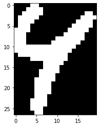

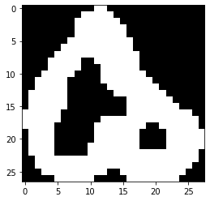

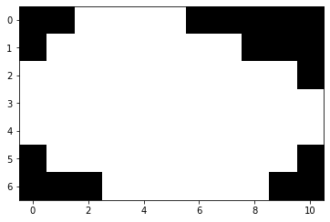

```python
plt.imshow(data[0],cmap="gray")
plt.show()

plt.imshow(data[7],cmap="gray")
plt.show()

plt.imshow(data[10],cmap="gray")
plt.show()

plt.imshow(data[100],cmap="gray")
plt.show()
```

[output not shown]

```python
print('Max: ',data[0].max())
print('Min: ',data[0].min())
```

```
Max:  255
Min:  0
```

## Resize images

```python
import cv2
resized_images = []
for image in data:
    resized_images.append(cv2.resize(image, (25,25), interpolation=cv2.INTER_CUBIC))

resized_images = np.array(resized_images)
```

```python
resized_images.shape
```

```
(102352, 25, 25)
```

## Train/Test Split

```python
from sklearn.model_selection import train_test_split
X_train, X_test, y_train, y_test = train_test_split(resized_images, labels, test_size=0.20, random_state=42)

X_train = np.array(X_train)
X_test = np.array(X_test)
y_train = np.array(y_train)
y_test = np.array(y_test)
```

## Show one image per category

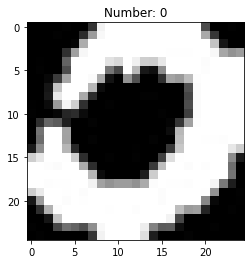

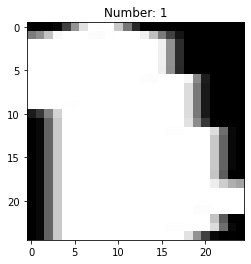

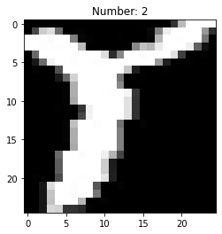

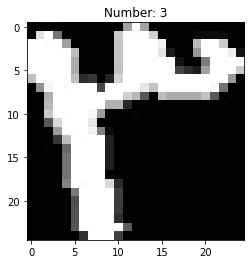

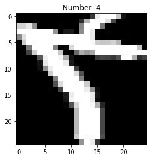

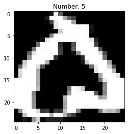

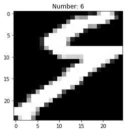

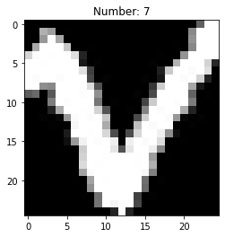

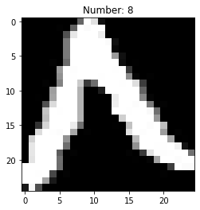

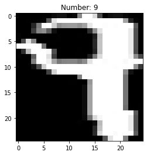

```python
selectedFromClass = [False]*10
indexes = [0]*10
i = 0
for label in y_train:
    if selectedFromClass[int(label)] == False:
        selectedFromClass[int(label)] = True
        indexes[int(label)] = i
    if selectedFromClass == [True]*10:
        break
    i += 1

number = 0;
for index in indexes:
    new_array = np.reshape(X_train[index], (25, 25))
    plt.imshow(new_array,cmap="gray")
    plt.title("Number: " + str(number) )
    plt.show()

    number += 1
```

```python
X_train.shape
```

```
(81881, 25, 25)
```

```python
X_test.shape
```

```
(20471, 25, 25)
```

## Plotting the frequency of classes

The classes in our dataset is fairly balanced.

```python
freqOfClassInTraining = {'0': 0, '1': 0, '2': 0, '3': 0, '4': 0,'5': 0, '6': 0, '7': 0, '8': 0, '9': 0}
for label in y_train:
    freqOfClassInTraining[str(label)] += 1
```

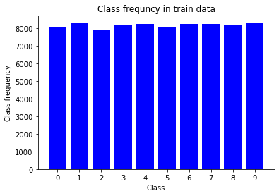

```python
plt.bar(freqOfClassInTraining.keys(), freqOfClassInTraining.values(), color='b')
plt.xlabel("Class")
plt.ylabel("Class frequency")
plt.title("Class frequncy in train data")
plt.show();
```

```python
freqOfClassInTest = {'0': 0, '1': 0, '2': 0, '3': 0, '4': 0,'5': 0, '6': 0, '7': 0, '8': 0, '9': 0}
for label in y_test:
    freqOfClassInTest[str(label)] += 1
```

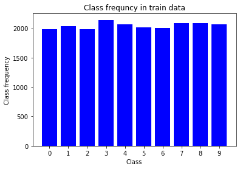

```python
plt.bar(freqOfClassInTest.keys(), freqOfClassInTest.values(), color='b')
plt.xlabel("Class")
plt.ylabel("Class frequency")
plt.title("Class frequncy in train data")
plt.show()
```

## Scaling the pixels

**Question: What would happen if we don't scale the pixels?** Neural networks process inputs using small weight values, and inputs with large integer values can disrupt or slow down the learning process. As such it is good practice to normalize the pixel values so that each pixel value has a value between 0 and 1.

```python
X_train = X_train/255
X_test = X_test/255

print("Max: ",X_train.max())
print("Min: ",X_train.min())
```

```
Max:  1.0
Min:  0.0
```

# Part 3

## 1) Training the model

```python
INPUT_SHAPE = 25*25
LEARNING_RATE = 1e-3
EPOCHS = 15
TRAINLOADER = Dataloader(X_train.reshape(-1,INPUT_SHAPE), y_train, 10, batch_size=32, shuffle=True)
TESTLOADER = Dataloader(X_test.reshape(-1,INPUT_SHAPE), y_test, 10, batch_size=32, shuffle=False)

network = FeedForwardNN(INPUT_SHAPE)
network.add_layer(35, activation=LeakyRelu(), weight_initializer='normal')
network.add_layer(10, activation=Identical(), weight_initializer='normal')
network.set_training_param(loss=CrossEntropy(), lr=LEARNING_RATE)

log = network.fit(EPOCHS, TRAINLOADER, TESTLOADER)
```

```
Epoch 1:
	Train: Average Accuracy: 9.873925361469324	Average Loss: 2.272596152475967
	Test: Average Accuracy: 9.710852581521738	Average Loss: 2.267676173615263
Epoch 2:
	Train: Average Accuracy: 9.870603751465417	Average Loss: 2.2638745669577856
	Test: Average Accuracy: 9.710852581521738	Average Loss: 2.2632729309678212
Epoch 3:
	Train: Average Accuracy: 9.881594372801876	Average Loss: 2.2593474284679593
	Test: Average Accuracy: 9.710852581521738	Average Loss: 2.2586527947015593
Epoch 4:
	Train: Average Accuracy: 9.878810082063305	Average Loss: 2.254658194454542
	Test: Average Accuracy: 9.710852581521738	Average Loss: 2.2536392684021846
Epoch 5:
	Train: Average Accuracy: 9.908460336068776	Average Loss: 2.249530836229871
	Test: Average Accuracy: 9.710852581521738	Average Loss: 2.2485429405333717
Epoch 6:
	Train: Average Accuracy: 9.947196170379055	Average Loss: 2.2441760118180567
	Test: Average Accuracy: 9.710852581521738	Average Loss: 2.2428062240587794
Epoch 7:
	Train: Average Accuracy: 9.990963266901133	Average Loss: 2.238214340873414
	Test: Average Accuracy: 9.779211956521738	Average Loss: 2.236882183051692
Epoch 8:
	Train: Average Accuracy: 10.389067995310668	Average Loss: 2.2318083184781874
	Test: Average Accuracy: 9.842688519021738	Average Loss: 2.229747297755005
Epoch 9:
	Train: Average Accuracy: 10.772030089878859	Average Loss: 2.2246038594484494
	Test: Average Accuracy: 10.57702105978261	Average Loss: 2.222356228331303
Epoch 10:
	Train: Average Accuracy: 11.327471668620555	Average Loss: 2.2166605204244605
	Test: Average Accuracy: 11.78307574728261	Average Loss: 2.213955233861487
Epoch 11:
	Train: Average Accuracy: 12.016217272372021	Average Loss: 2.2077921330861687
	Test: Average Accuracy: 12.59362262228261	Average Loss: 2.2046161950935295
Epoch 12:
	Train: Average Accuracy: 12.841197733489645	Average Loss: 2.197868428732944
	Test: Average Accuracy: 14.138502038043478	Average Loss: 2.1943352046316784
Epoch 13:
	Train: Average Accuracy: 13.658167252833138	Average Loss: 2.1867003702729018
	Test: Average Accuracy: 13.850416100543478	Average Loss: 2.182354311061239
Epoch 14:
	Train: Average Accuracy: 14.316041422430636	Average Loss: 2.1741613211973028
	Test: Average Accuracy: 14.133619225543478	Average Loss: 2.1689994068220715
Epoch 15:
	Train: Average Accuracy: 14.909730363423213	Average Loss: 2.160046871513776
	Test: Average Accuracy: 14.919752038043478	Average Loss: 2.1539694083874337
```

## 2) What would happen if we assign zero weights & biases to our model?

Initializing all the weights with zeros leads the neurons to learn the same features during training. In fact, any constant initialization scheme will perform very poorly. Consider a neural network with two hidden units, and assume we initialize all the biases to 0 and the weights with some constant `α`. (Source: deeplearning.ai)

## 3) Learning Rate

Learning rate shows that how much our network should be updated when we have some error. When it is high, for little changes we have big updates which is not good because we not seeing hole data, that is just one batch of data. Also when it is low we change a little that like that we are not updating netowrk, again this is not good.

The best learning rate that I found was $1e-4$

```python
%time
INPUT_SHAPE = 25*25
LEARNING_RATE = 1e-4
EPOCHS = 15
TRAINLOADER = Dataloader(X_train.reshape(-1,INPUT_SHAPE), y_train, 10, batch_size=32, shuffle=True)
TESTLOADER = Dataloader(X_test.reshape(-1,INPUT_SHAPE), y_test, 10, batch_size=32, shuffle=False)

network = FeedForwardNN(INPUT_SHAPE)
network.add_layer(35, activation=LeakyRelu(), weight_initializer='normal')
network.add_layer(10, activation=Identical(), weight_initializer='normal')
network.set_training_param(loss=CrossEntropy(), lr=LEARNING_RATE)

log = network.fit(EPOCHS, TRAINLOADER, TESTLOADER)
```

```
CPU times: user 2 µs, sys: 1 µs, total: 3 µs
Wall time: 5.96 µs
Epoch 1:
	Train: Average Accuracy: 59.62172723720203	Average Loss: 1.2631629783684781
	Test: Average Accuracy: 85.64665421195653	Average Loss: 0.49981395401327766
Epoch 2:
	Train: Average Accuracy: 89.21751660805002	Average Loss: 0.3637215255819128
	Test: Average Accuracy: 91.00309952445653	Average Loss: 0.29576150657606176
Epoch 3:
	Train: Average Accuracy: 92.94455842125831	Average Loss: 0.24944397439117658
	Test: Average Accuracy: 93.46000339673913	Average Loss: 0.23007673474797974
Epoch 4:
	Train: Average Accuracy: 94.08948808128176	Average Loss: 0.21053871120766648
	Test: Average Accuracy: 93.99222995923913	Average Loss: 0.20917281568389895
Epoch 5:
	Train: Average Accuracy: 94.58006057053537	Average Loss: 0.1905111224861358
	Test: Average Accuracy: 94.50004245923913	Average Loss: 0.18939484763928044
Epoch 6:
	Train: Average Accuracy: 95.00014654161782	Average Loss: 0.1779662575770194
	Test: Average Accuracy: 94.79789402173913	Average Loss: 0.17935577424110244
Epoch 7:
	Train: Average Accuracy: 95.24316139116843	Average Loss: 0.16930044276469436
	Test: Average Accuracy: 94.99808933423913	Average Loss: 0.174568565111413
Epoch 8:
	Train: Average Accuracy: 95.48373388042204	Average Loss: 0.162579894461041
	Test: Average Accuracy: 95.33988620923913	Average Loss: 0.16700393992007193
Epoch 9:
	Train: Average Accuracy: 95.61772176631497	Average Loss: 0.1572411843892903
	Test: Average Accuracy: 95.43265964673913	Average Loss: 0.16232031559287088
Epoch 10:
	Train: Average Accuracy: 95.80158264947245	Average Loss: 0.15292363935664757
	Test: Average Accuracy: 95.51078464673913	Average Loss: 0.15993577252380445
Epoch 11:
	Train: Average Accuracy: 95.8802754982415	Average Loss: 0.14936072663964214
	Test: Average Accuracy: 95.69144870923913	Average Loss: 0.1560678388478996
Epoch 12:
	Train: Average Accuracy: 95.93713364595546	Average Loss: 0.1462919947738593
	Test: Average Accuracy: 95.80863620923913	Average Loss: 0.15328825051576872
Epoch 13:
	Train: Average Accuracy: 96.04914028917545	Average Loss: 0.1431514571434804
	Test: Average Accuracy: 95.81351902173913	Average Loss: 0.1492301832470982
Epoch 14:
	Train: Average Accuracy: 96.10932004689332	Average Loss: 0.1407439710528374
	Test: Average Accuracy: 95.90629245923913	Average Loss: 0.148191527783205
Epoch 15:
	Train: Average Accuracy: 96.21312035951543	Average Loss: 0.138329779571271
	Test: Average Accuracy: 95.91605808423913	Average Loss: 0.14727390239715552
```

### Higher learning rate

The learning rate $1e-3$ was experimented previously.

### Lower learning rate

$ lr = 1e-5 $

```python
INPUT_SHAPE = 25*25
LEARNING_RATE = 1e-5
EPOCHS = 15
TRAINLOADER = Dataloader(X_train.reshape(-1,INPUT_SHAPE), y_train, 10, batch_size=32, shuffle=True)
TESTLOADER = Dataloader(X_test.reshape(-1,INPUT_SHAPE), y_test, 10, batch_size=32, shuffle=False)

network = FeedForwardNN(INPUT_SHAPE)
network.add_layer(35, activation=LeakyRelu(), weight_initializer='normal')
network.add_layer(10, activation=Identical(), weight_initializer='normal')
network.set_training_param(loss=CrossEntropy(), lr=LEARNING_RATE)

log = network.fit(EPOCHS, TRAINLOADER, TESTLOADER)
```

```
Epoch 1:
	Train: Average Accuracy: 10.687035951543571	Average Loss: 2.2440953379571544
	Test: Average Accuracy: 9.881751019021738	Average Loss: 2.2065957494842414
Epoch 2:
	Train: Average Accuracy: 15.83167252833138	Average Loss: 2.1268497566471694
	Test: Average Accuracy: 25.359205163043477	Average Loss: 2.0173236728772217
Epoch 3:
	Train: Average Accuracy: 43.82962094568191	Average Loss: 1.8333943247872342
	Test: Average Accuracy: 61.45741338315217	Average Loss: 1.633466747788922
Epoch 4:
	Train: Average Accuracy: 68.11503516998827	Average Loss: 1.4316020310754702
	Test: Average Accuracy: 73.15174932065217	Average Loss: 1.2519298779110488
Epoch 5:
	Train: Average Accuracy: 76.24057248925361	Average Loss: 1.1045966753600889
	Test: Average Accuracy: 79.05698029891305	Average Loss: 0.9784191651721542
Epoch 6:
	Train: Average Accuracy: 79.89786049237983	Average Loss: 0.877458556862092
	Test: Average Accuracy: 80.82455842391305	Average Loss: 0.7954049321468432
Epoch 7:
	Train: Average Accuracy: 82.04762602579133	Average Loss: 0.7268582277628565
	Test: Average Accuracy: 82.79127038043478	Average Loss: 0.6733689167391748
Epoch 8:
	Train: Average Accuracy: 83.70110394685425	Average Loss: 0.6260186515431851
	Test: Average Accuracy: 84.29517663043478	Average Loss: 0.5896870414520745
Epoch 9:
	Train: Average Accuracy: 84.94636576787808	Average Loss: 0.5545574995951335
	Test: Average Accuracy: 85.40548573369566	Average Loss: 0.5297414592825505
Epoch 10:
	Train: Average Accuracy: 85.8754884720594	Average Loss: 0.5010528706244477
	Test: Average Accuracy: 86.43087635869566	Average Loss: 0.4826006672034362
Epoch 11:
	Train: Average Accuracy: 86.77271395076201	Average Loss: 0.4589240734276284
	Test: Average Accuracy: 87.26095448369566	Average Loss: 0.44410660458293305
Epoch 12:
	Train: Average Accuracy: 87.55636967565455	Average Loss: 0.42462369893038093
	Test: Average Accuracy: 88.06555706521739	Average Loss: 0.41314910887046874
Epoch 13:
	Train: Average Accuracy: 88.33983001172334	Average Loss: 0.3959591970823109
	Test: Average Accuracy: 88.71688179347827	Average Loss: 0.387047131946671
Epoch 14:
	Train: Average Accuracy: 89.05720007815553	Average Loss: 0.3717974380683146
	Test: Average Accuracy: 89.33211616847827	Average Loss: 0.36437627206205114
Epoch 15:
	Train: Average Accuracy: 89.7555197342712	Average Loss: 0.35088264790179474
	Test: Average Accuracy: 89.95223335597827	Average Loss: 0.34623265674954473
```

# 4) Activation Functions

## Dying ReLU

The downside for being zero for all negative values is a problem called “dying ReLU.”

A ReLU neuron is “dead” if it’s stuck in the negative side and always outputs 0. Because the slope of ReLU in the negative range is also 0, once a neuron gets negative, it’s unlikely for it to recover. Such neurons are not playing any role in discriminating the input and is essentially useless. Over the time you may end up with a large part of your network doing nothing.

You may be confused as of how this zero-slope section works in the first place. Remember that a single step (in SGD, for example) involves multiple data points. As long as not all of them are negative, we can still get a slope out of ReLU. The dying problem is likely to occur when learning rate is too high or there is a large negative bias.

## Why leaky ReLU is better?

It fixes the `dying ReLU` problem, as it doesn’t have zero-slope parts. It speeds up training. There is evidence that having the `mean activation` be close to 0 makes training faster. (It helps keep off-diagonal entries of the Fisher information matrix small, but you can safely ignore this.) Unlike ReLU, leaky ReLU is more `balanced,` and may therefore learn faster.

## Why tanh & sigmoid are not good?

The down side of this is that if you have many layers, you will multiply these gradients, and the product of many smaller than 1 values goes to zero very quickly.

Since the state of the art of for Deep Learning has shown that more layers helps a lot, then this disadvantage of the Sigmoid function is a game killer. You just can't do Deep Learning with Sigmoid.This vanish network.This happens with tanh as well.

## Leaky ReLU

```python
%time
INPUT_SHAPE = 25*25
LEARNING_RATE = 1e-4
EPOCHS = 15
TRAINLOADER = Dataloader(X_train.reshape(-1,INPUT_SHAPE), y_train, 10, batch_size=32, shuffle=True)
TESTLOADER = Dataloader(X_test.reshape(-1,INPUT_SHAPE), y_test, 10, batch_size=32, shuffle=False)

network = FeedForwardNN(INPUT_SHAPE)
network.add_layer(35, activation=LeakyRelu(), weight_initializer='normal')
network.add_layer(10, activation=Identical(), weight_initializer='normal')
network.set_training_param(loss=CrossEntropy(), lr=LEARNING_RATE)

log = network.fit(EPOCHS, TRAINLOADER, TESTLOADER)
```

```
CPU times: user 2 µs, sys: 1 µs, total: 3 µs
Wall time: 5.96 µs
Epoch 1:
	Train: Average Accuracy: 59.62172723720203	Average Loss: 1.2631629783684781
	Test: Average Accuracy: 85.64665421195653	Average Loss: 0.49981395401327766
Epoch 2:
	Train: Average Accuracy: 89.21751660805002	Average Loss: 0.3637215255819128
	Test: Average Accuracy: 91.00309952445653	Average Loss: 0.29576150657606176
Epoch 3:
	Train: Average Accuracy: 92.94455842125831	Average Loss: 0.24944397439117658
	Test: Average Accuracy: 93.46000339673913	Average Loss: 0.23007673474797974
Epoch 4:
	Train: Average Accuracy: 94.08948808128176	Average Loss: 0.21053871120766648
	Test: Average Accuracy: 93.99222995923913	Average Loss: 0.20917281568389895
Epoch 5:
	Train: Average Accuracy: 94.58006057053537	Average Loss: 0.1905111224861358
	Test: Average Accuracy: 94.50004245923913	Average Loss: 0.18939484763928044
Epoch 6:
	Train: Average Accuracy: 95.00014654161782	Average Loss: 0.1779662575770194
	Test: Average Accuracy: 94.79789402173913	Average Loss: 0.17935577424110244
Epoch 7:
	Train: Average Accuracy: 95.24316139116843	Average Loss: 0.16930044276469436
	Test: Average Accuracy: 94.99808933423913	Average Loss: 0.174568565111413
Epoch 8:
	Train: Average Accuracy: 95.48373388042204	Average Loss: 0.162579894461041
	Test: Average Accuracy: 95.33988620923913	Average Loss: 0.16700393992007193
Epoch 9:
	Train: Average Accuracy: 95.61772176631497	Average Loss: 0.1572411843892903
	Test: Average Accuracy: 95.43265964673913	Average Loss: 0.16232031559287088
Epoch 10:
	Train: Average Accuracy: 95.80158264947245	Average Loss: 0.15292363935664757
	Test: Average Accuracy: 95.51078464673913	Average Loss: 0.15993577252380445
Epoch 11:
	Train: Average Accuracy: 95.8802754982415	Average Loss: 0.14936072663964214
	Test: Average Accuracy: 95.69144870923913	Average Loss: 0.1560678388478996
Epoch 12:
	Train: Average Accuracy: 95.93713364595546	Average Loss: 0.1462919947738593
	Test: Average Accuracy: 95.80863620923913	Average Loss: 0.15328825051576872
Epoch 13:
	Train: Average Accuracy: 96.04914028917545	Average Loss: 0.1431514571434804
	Test: Average Accuracy: 95.81351902173913	Average Loss: 0.1492301832470982
Epoch 14:
	Train: Average Accuracy: 96.10932004689332	Average Loss: 0.1407439710528374
	Test: Average Accuracy: 95.90629245923913	Average Loss: 0.148191527783205
Epoch 15:
	Train: Average Accuracy: 96.21312035951543	Average Loss: 0.138329779571271
	Test: Average Accuracy: 95.91605808423913	Average Loss: 0.14727390239715552
```

## Tanh

```python
%time
INPUT_SHAPE = 25*25
LEARNING_RATE = 1e-4
EPOCHS = 15
TRAINLOADER = Dataloader(X_train.reshape(-1,INPUT_SHAPE), y_train, 10, batch_size=32, shuffle=True)
TESTLOADER = Dataloader(X_test.reshape(-1,INPUT_SHAPE), y_test, 10, batch_size=32, shuffle=False)

network = FeedForwardNN(INPUT_SHAPE)
network.add_layer(35, activation=Tanh(), weight_initializer='normal')
network.add_layer(10, activation=Identical(), weight_initializer='normal')
network.set_training_param(loss=CrossEntropy(), lr=LEARNING_RATE)

log = network.fit(EPOCHS, TRAINLOADER, TESTLOADER)
```

```
CPU times: user 2 µs, sys: 1e+03 ns, total: 3 µs
Wall time: 5.96 µs
Epoch 1:
	Train: Average Accuracy: 9.907239155920282	Average Loss: 2.303382612896916
	Test: Average Accuracy: 10.20210597826087	Average Loss: 2.303614646070749
Epoch 2:
	Train: Average Accuracy: 10.013139898397812	Average Loss: 2.303344750977592
	Test: Average Accuracy: 10.20210597826087	Average Loss: 2.3028393773530853
Epoch 3:
	Train: Average Accuracy: 10.254738178976163	Average Loss: 2.3028864777923936
	Test: Average Accuracy: 9.775390625	Average Loss: 2.3035989716129928
Epoch 4:
	Train: Average Accuracy: 20.539859320046894	Average Loss: 2.235787309850435
	Test: Average Accuracy: 28.931300951086957	Average Loss: 2.0807767468061877
Epoch 5:
	Train: Average Accuracy: 44.55451348182884	Average Loss: 1.7959967402512305
	Test: Average Accuracy: 62.37049932065217	Average Loss: 1.4439118860427544
Epoch 6:
	Train: Average Accuracy: 65.42843884329817	Average Loss: 1.2295285778054528
	Test: Average Accuracy: 70.38319463315217	Average Loss: 1.072850889221413
Epoch 7:
	Train: Average Accuracy: 72.1072196170379	Average Loss: 0.9786694850660782
	Test: Average Accuracy: 73.12436311141305	Average Loss: 0.9035959448482254
Epoch 8:
	Train: Average Accuracy: 72.92296795623291	Average Loss: 0.8607261392216669
	Test: Average Accuracy: 72.07753057065217	Average Loss: 0.8274152908372834
Epoch 9:
	Train: Average Accuracy: 76.41222157092615	Average Loss: 0.7441378505217865
	Test: Average Accuracy: 82.26880944293478	Average Loss: 0.628963141568495
Epoch 10:
	Train: Average Accuracy: 85.09080695584213	Average Loss: 0.5380866463994086
	Test: Average Accuracy: 86.87032948369566	Average Loss: 0.4774187908472062
Epoch 11:
	Train: Average Accuracy: 88.38310863618601	Average Loss: 0.4188365176205156
	Test: Average Accuracy: 89.32447350543478	Average Loss: 0.38326150746686855
Epoch 12:
	Train: Average Accuracy: 90.55070339976554	Average Loss: 0.3395819840218327
	Test: Average Accuracy: 90.87423573369566	Average Loss: 0.32271210105691656
Epoch 13:
	Train: Average Accuracy: 91.68307932786244	Average Loss: 0.2927102312631135
	Test: Average Accuracy: 91.83020550271739	Average Loss: 0.29006780096877405
Epoch 14:
	Train: Average Accuracy: 92.47127784290738	Average Loss: 0.26541686159755584
	Test: Average Accuracy: 92.49426800271739	Average Loss: 0.2676156380229622
Epoch 15:
	Train: Average Accuracy: 93.01050214927706	Average Loss: 0.24608130173875384
	Test: Average Accuracy: 92.90145210597827	Average Loss: 0.2506170608966295
```

## Sigmoid

```python
%time
INPUT_SHAPE = 25*25
LEARNING_RATE = 1e-4
EPOCHS = 15
TRAINLOADER = Dataloader(X_train.reshape(-1,INPUT_SHAPE), y_train, 10, batch_size=32, shuffle=True)
TESTLOADER = Dataloader(X_test.reshape(-1,INPUT_SHAPE), y_test, 10, batch_size=32, shuffle=False)

network = FeedForwardNN(INPUT_SHAPE)
network.add_layer(35, activation=Sigmoid(), weight_initializer='normal')
network.add_layer(10, activation=Identical(), weight_initializer='normal')
network.set_training_param(loss=CrossEntropy(), lr=LEARNING_RATE)

log = network.fit(EPOCHS, TRAINLOADER, TESTLOADER)
```

```
CPU times: user 55 µs, sys: 1e+03 ns, total: 56 µs
Wall time: 7.87 µs
Epoch 1:
	Train: Average Accuracy: 10.082405236420477	Average Loss: 2.3033427569358373
	Test: Average Accuracy: 9.775390625	Average Loss: 2.3034971473793653
Epoch 2:
	Train: Average Accuracy: 10.132278233685033	Average Loss: 2.302889456827243
	Test: Average Accuracy: 9.933338994565217	Average Loss: 2.303441287396958
Epoch 3:
	Train: Average Accuracy: 10.372508792497069	Average Loss: 2.302425272568302
	Test: Average Accuracy: 9.775390625	Average Loss: 2.302276907894252
Epoch 4:
	Train: Average Accuracy: 10.987104337631887	Average Loss: 2.300972863542566
	Test: Average Accuracy: 10.116126019021738	Average Loss: 2.299733686065484
Epoch 5:
	Train: Average Accuracy: 13.464536928487691	Average Loss: 2.295252527377857
	Test: Average Accuracy: 18.195270040760867	Average Loss: 2.286070988004592
Epoch 6:
	Train: Average Accuracy: 23.04362055490426	Average Loss: 2.248073091481629
	Test: Average Accuracy: 27.650093410326086	Average Loss: 2.186061738610332
Epoch 7:
	Train: Average Accuracy: 33.08689917936694	Average Loss: 2.0990821106496482
	Test: Average Accuracy: 40.02908457880435	Average Loss: 2.000643121059672
Epoch 8:
	Train: Average Accuracy: 42.036781946072686	Average Loss: 1.8926531531375461
	Test: Average Accuracy: 44.60130774456522	Average Loss: 1.7680587554942906
Epoch 9:
	Train: Average Accuracy: 57.373339194998046	Average Loss: 1.6258138428426978
	Test: Average Accuracy: 67.1390964673913	Average Loss: 1.4713482608906188
Epoch 10:
	Train: Average Accuracy: 70.13818874560376	Average Loss: 1.3150359291381635
	Test: Average Accuracy: 71.64487092391305	Average Loss: 1.172495663592428
Epoch 11:
	Train: Average Accuracy: 73.30417155138726	Average Loss: 1.0639209711368542
	Test: Average Accuracy: 75.04819123641305	Average Loss: 0.9778810354280758
Epoch 12:
	Train: Average Accuracy: 76.04152012504885	Average Loss: 0.9089262422572943
	Test: Average Accuracy: 76.9983440896739	Average Loss: 0.8560101382972167
Epoch 13:
	Train: Average Accuracy: 78.42843884329817	Average Loss: 0.8041447805983759
	Test: Average Accuracy: 79.21896229619566	Average Loss: 0.7658733707016958
Epoch 14:
	Train: Average Accuracy: 80.39292692457991	Average Loss: 0.7211712262095624
	Test: Average Accuracy: 80.82540760869566	Average Loss: 0.6912890091048574
Epoch 15:
	Train: Average Accuracy: 82.05915396639313	Average Loss: 0.6483068776836319
	Test: Average Accuracy: 82.63204823369566	Average Loss: 0.6204523790715667
```

# 5) Batch Size

The batch size defines the number of samples that will be propagated through the network.

For instance, let's say you have 1050 training samples and you want to set up a batch_size equal to 100. The algorithm takes the first 100 samples (from 1st to 100th) from the training dataset and trains the network. Next, it takes the second 100 samples (from 101st to 200th) and trains the network again. We can keep doing this procedure until we have propagated all samples through of the network. Problem might happen with the last set of samples. In our example, we've used 1050 which is not divisible by 100 without remainder. The simplest solution is just to get the final 50 samples and train the network.

Advantages of using a batch size < number of all samples:

- It requires less memory. Since you train the network using fewer samples, the overall training procedure requires less memory. That's especially important if you are not able to fit the whole dataset in your machine's memory.
- Typically networks train faster with mini-batches. That's because we update the weights after each propagation. In our example we've propagated 11 batches (10 of them had 100 samples and 1 had 50 samples) and after each of them we've updated our network's parameters. If we used all samples during propagation we would make only 1 update for the network's parameter.
- Updating network is with considering more data.

Smaller batch sizes are used for two main reasons: Smaller batch sizes are noisy, offering a regularizing effect and lower generalization error. Smaller batch sizes make it easier to fit one batch worth of training data in memory.

Higher batch size means less training time. But higher batch size requires higher memory as well. With batch_size=16 it took 5 mins longer to train the model. With batch_size = 256 it took 50 seconds to train the model. But the accuracy of the model was reduced drastically with 256 batch size.

## batch_size = 16

```python
%time
INPUT_SHAPE = 25*25
LEARNING_RATE = 1e-4
EPOCHS = 15
TRAINLOADER = Dataloader(X_train.reshape(-1,INPUT_SHAPE), y_train, 10, batch_size=16, shuffle=True)
TESTLOADER = Dataloader(X_test.reshape(-1,INPUT_SHAPE), y_test, 10, batch_size=16, shuffle=False)

network = FeedForwardNN(INPUT_SHAPE)
network.add_layer(35, activation=LeakyRelu(), weight_initializer='normal')
network.add_layer(10, activation=Identical(), weight_initializer='normal')
network.set_training_param(loss=CrossEntropy(), lr=LEARNING_RATE)

log = network.fit(EPOCHS, TRAINLOADER, TESTLOADER)
```

```
CPU times: user 2 µs, sys: 1 µs, total: 3 µs
Wall time: 5.96 µs
Epoch 1:
	Train: Average Accuracy: 60.12141244409708	Average Loss: 1.2491338331215422
	Test: Average Accuracy: 85.79799107142858	Average Loss: 0.49643069579961613
Epoch 2:
	Train: Average Accuracy: 89.57627762580869	Average Loss: 0.3604577002422166
	Test: Average Accuracy: 91.8701171875	Average Loss: 0.2848003256671888
Epoch 3:
	Train: Average Accuracy: 92.92109005253788	Average Loss: 0.24915591438485263
	Test: Average Accuracy: 93.3837890625	Average Loss: 0.22926615268880282
Epoch 4:
	Train: Average Accuracy: 93.98690894880812	Average Loss: 0.21177692454819189
	Test: Average Accuracy: 94.072265625	Average Loss: 0.2060805609136401
Epoch 5:
	Train: Average Accuracy: 94.57918132082845	Average Loss: 0.1921671575891623
	Test: Average Accuracy: 94.5263671875	Average Loss: 0.19229832040089923
Epoch 6:
	Train: Average Accuracy: 94.8725359298337	Average Loss: 0.1795142378338889
	Test: Average Accuracy: 94.833984375	Average Loss: 0.18172593957865382
Epoch 7:
	Train: Average Accuracy: 95.17145369284877	Average Loss: 0.17084064135305446
	Test: Average Accuracy: 95.0390625	Average Loss: 0.17449339772392164
Epoch 8:
	Train: Average Accuracy: 95.42790152403282	Average Loss: 0.16385899594132705
	Test: Average Accuracy: 95.1708984375	Average Loss: 0.1694678440320627
Epoch 9:
	Train: Average Accuracy: 95.59208241066388	Average Loss: 0.1589326555157474
	Test: Average Accuracy: 95.361328125	Average Loss: 0.1645152449341129
Epoch 10:
	Train: Average Accuracy: 95.70510941774131	Average Loss: 0.15426645357959748
	Test: Average Accuracy: 95.5029296875	Average Loss: 0.15992579146407246
Epoch 11:
	Train: Average Accuracy: 95.82600625244235	Average Loss: 0.15040008859002882
	Test: Average Accuracy: 95.5859375	Average Loss: 0.1582222185758467
Epoch 12:
	Train: Average Accuracy: 95.89222135382745	Average Loss: 0.1473848900939446
	Test: Average Accuracy: 95.4248046875	Average Loss: 0.15923402588254038
Epoch 13:
	Train: Average Accuracy: 95.99575029308323	Average Loss: 0.1447029041715456
	Test: Average Accuracy: 95.791015625	Average Loss: 0.15201421821454994
Epoch 14:
	Train: Average Accuracy: 96.09832942555686	Average Loss: 0.14243154045200834
	Test: Average Accuracy: 95.8251953125	Average Loss: 0.14982887516434457
Epoch 15:
	Train: Average Accuracy: 96.07268464243845	Average Loss: 0.14032822224473226
	Test: Average Accuracy: 95.7666015625	Average Loss: 0.14823568198324852
```

## batch_size = 256

```python
%time
INPUT_SHAPE = 25*25
LEARNING_RATE = 1e-4
EPOCHS = 15
TRAINLOADER = Dataloader(X_train.reshape(-1,INPUT_SHAPE), y_train, 10, batch_size=256, shuffle=True)
TESTLOADER = Dataloader(X_test.reshape(-1,INPUT_SHAPE), y_test, 10, batch_size=256, shuffle=False)

network = FeedForwardNN(INPUT_SHAPE)
network.add_layer(35, activation=LeakyRelu(), weight_initializer='normal')
network.add_layer(10, activation=Identical(), weight_initializer='normal')
network.set_training_param(loss=CrossEntropy(), lr=LEARNING_RATE)

log = network.fit(EPOCHS, TRAINLOADER, TESTLOADER)
```

```
CPU times: user 3 µs, sys: 1 µs, total: 4 µs
Wall time: 6.91 µs
Epoch 1:
```

```
	Train: Average Accuracy: 9.88832535282258	Average Loss: nan
	Test: Average Accuracy: 9.71183498861336	Average Loss: nan
Epoch 2:
	Train: Average Accuracy: 9.870987993231568	Average Loss: nan
	Test: Average Accuracy: 9.71183498861336	Average Loss: nan
Epoch 3:
	Train: Average Accuracy: 9.869671658986174	Average Loss: nan
	Test: Average Accuracy: 9.71183498861336	Average Loss: nan
Epoch 4:
	Train: Average Accuracy: 9.869232880904377	Average Loss: nan
	Test: Average Accuracy: 9.71183498861336	Average Loss: nan
Epoch 5:
	Train: Average Accuracy: 9.868574713781681	Average Loss: nan
	Test: Average Accuracy: 9.71183498861336	Average Loss: nan
Epoch 6:
	Train: Average Accuracy: 9.87208493843606	Average Loss: nan
	Test: Average Accuracy: 9.71183498861336	Average Loss: nan
Epoch 7:
	Train: Average Accuracy: 9.869452269945276	Average Loss: nan
	Test: Average Accuracy: 9.71183498861336	Average Loss: nan
Epoch 8:
	Train: Average Accuracy: 9.870549215149769	Average Loss: nan
	Test: Average Accuracy: 9.71183498861336	Average Loss: nan
Epoch 9:
	Train: Average Accuracy: 9.870768604190669	Average Loss: nan
	Test: Average Accuracy: 9.71183498861336	Average Loss: nan
Epoch 10:
	Train: Average Accuracy: 9.869891048027075	Average Loss: nan
	Test: Average Accuracy: 9.71183498861336	Average Loss: nan
Epoch 11:
	Train: Average Accuracy: 9.870987993231568	Average Loss: nan
	Test: Average Accuracy: 9.71183498861336	Average Loss: nan
Epoch 12:
	Train: Average Accuracy: 9.869671658986174	Average Loss: nan
	Test: Average Accuracy: 9.71183498861336	Average Loss: nan
Epoch 13:
	Train: Average Accuracy: 9.870110437067973	Average Loss: nan
	Test: Average Accuracy: 9.71183498861336	Average Loss: nan
Epoch 14:
	Train: Average Accuracy: 9.870549215149769	Average Loss: nan
	Test: Average Accuracy: 9.71183498861336	Average Loss: nan
Epoch 15:
	Train: Average Accuracy: 9.87208493843606	Average Loss: nan
	Test: Average Accuracy: 9.71183498861336	Average Loss: nan
```